# Concentration of CO2 in the Atmosphere Since 1958

Kadir Korkmaz

11/24/2018

## Introduction

In this document, I have analyzed the concentration of CO2 change in the Atmosphere since 1958. You can access the original version of the dataset from [this](http://scrippsco2.ucsd.edu/data/atmospheric_co2/primary_mlo_co2_record) link. Dataset is updated continuously and I worked on the snapshot of the dataset which is taken at 11/24/2018. Snapshot of the dataset will be available with this document to facilitate reproducibility.

## Loading Dataset

In Data folder we have a CSV file contains weekly measurements of CO2 concentration. CSV file contains some comments related to data so we skipped that part when we are loading the data. Also, CSV file does not contain header so after loading the dataset I added column names.

```r
#Loading data from CSV file
weekly_co2_concentration = read.csv("./data/weekly_in_situ_co2_mlo.csv", header = FALSE, skip=44)

#Adding header
colnames(weekly_co2_concentration)=c("date","concentration")

#Parsing date field
weekly_co2_concentration$date <- as.Date(weekly_co2_concentration$date,format="%Y-%m-%d")
```

## A First Look to the Dataset

Weekly measurement dataset contains only two columns. Explanation of the column values are given on the comment section of the CSV file as follows:

> The data file below contains 2 columns indicating the date and CO2 concentrations in micro-mol CO2 per mole (ppm), reported on the 2008A SIO manometric mole fraction scale. These weekly values have been adjusted to 12:00 hours at the middle day of each weekly period as indicated by the date in the first column.

You can find the first few lines of the weekly measurement dataset on the following table.

```r
head(weekly_co2_concentration)
```

```
##         date concentration
## 1 1958-03-29        316.19
## 2 1958-04-05        317.31
## 3 1958-04-12        317.69
## 4 1958-04-19        317.58
## 5 1958-04-26        316.48
## 6 1958-05-03        316.95
```

## Observation of the Global Trend and Seasonal Trend

When we plot the weekly measurement data set we can easily observe the [Keeling Curve](https://en.wikipedia.org/wiki/Keeling_Curve). CO2 Concentration in the Atmosphere is increasing by years.

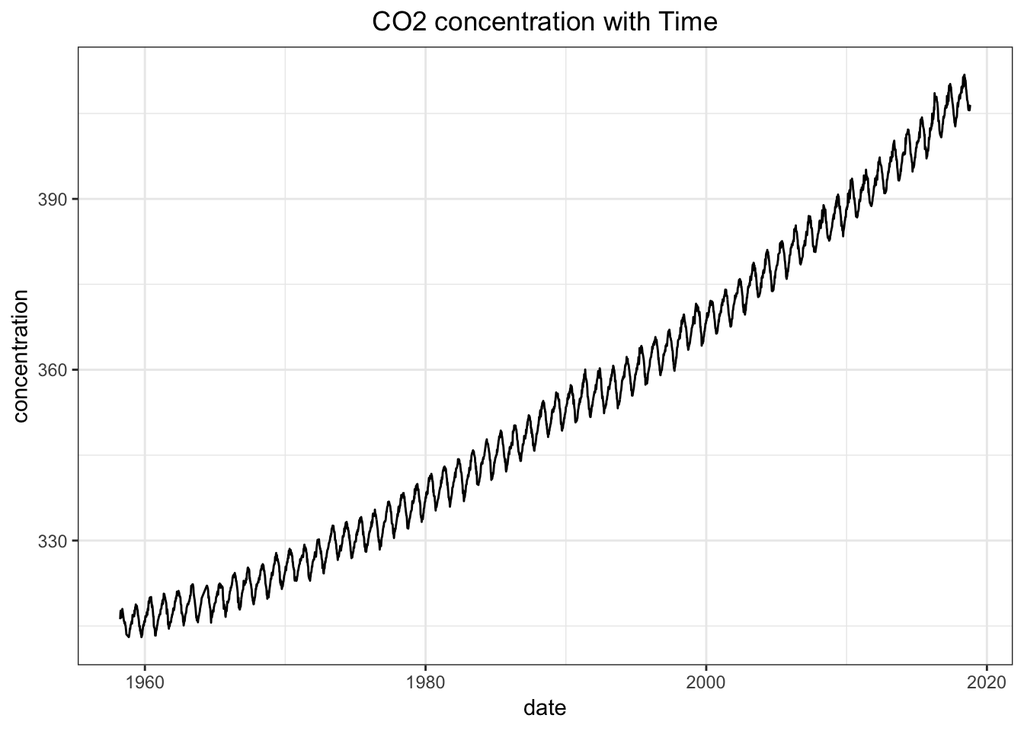

```r
library(ggplot2)

ggplot(weekly_co2_concentration, aes(date, concentration)) +
    geom_line() + theme_bw() +
    ggtitle("CO2 concentration with Time") +
    theme(plot.title = element_text(hjust = 0.5))
```

When we look closer to the data there is a cycle related CO2 Concentration according to seasons. The following graph draws the CO2 concentration of 2015, 2016 and 2017 years to observe the seasonal trend better.

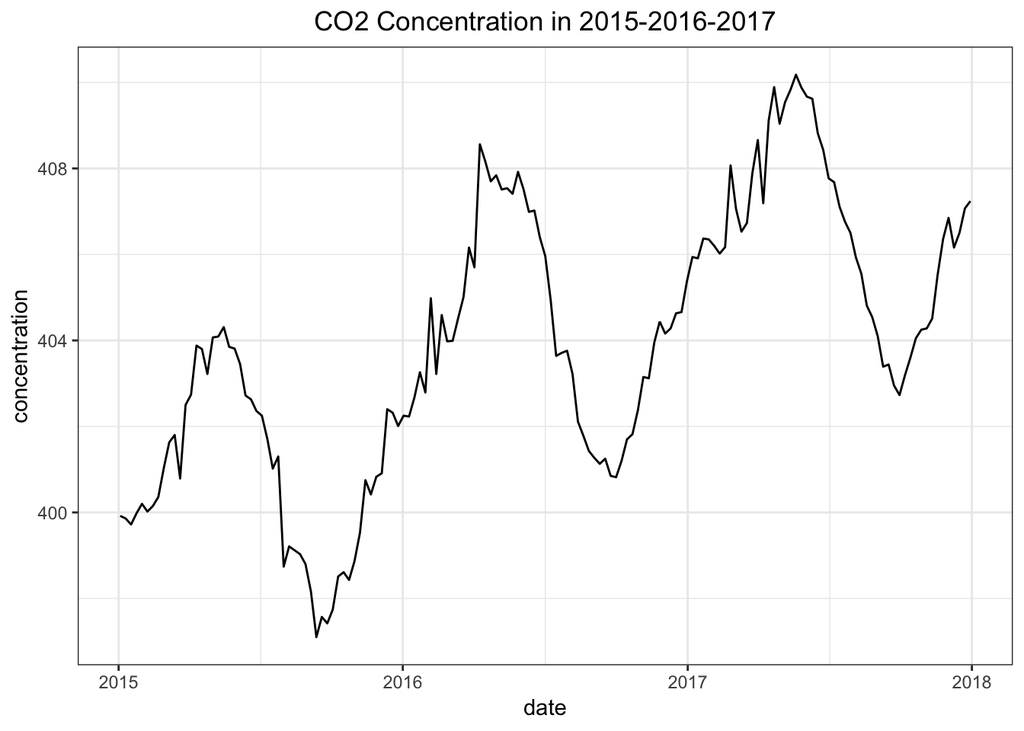

```r
#Plotting subset of the data to see the seasonal cycle
ggplot(weekly_co2_concentration[weekly_co2_concentration$date > "2014-12-31" & weekly_co2_concentration$date < "2018-01-01" ,], aes(date, concentration)) +
  geom_line() + theme_bw() +
  ggtitle("CO2 Concentration in 2015-2016-2017") +
  theme(plot.title = element_text(hjust = 0.5))
```

## Selection of a model to predict future CO2 concentrations

I used the ANOVA function of R to compare the performance of models in terms of how the model explains the variance. I have selected the model when the new model with extra variable does not explain extra variance in the sample data.

I have created 7 models. *m1* is the linear model and others(m2 to m7) are the higher order polynomial models. With the help of ANOVA function I saw that adding 7 terms did not contribute to explaining variance in the data so I have chosen model 6 as my final model to predict the future.

(*Later, I observed that model 6 (m6) is making a strange extrapolation which is not expected. The higher order polynomial model explains the variance in the sample data better than lower order polynomial models but it is not making good future predictions. I observed this fact by experiments.*)

```r
library(ggplot2)
library("dplyr")
#We can not use date field in calculations so I am creating another field to represent date field
weekly_co2_concentration <- weekly_co2_concentration %>% mutate(index = row_number())
weekly_co2_concentration <- weekly_co2_concentration %>% mutate(index2 = row_number()^2)
weekly_co2_concentration <- weekly_co2_concentration %>% mutate(index3 = row_number()^3)
weekly_co2_concentration <- weekly_co2_concentration %>% mutate(index4 = row_number()^4)
weekly_co2_concentration <- weekly_co2_concentration %>% mutate(index5 = row_number()^5)
weekly_co2_concentration <- weekly_co2_concentration %>% mutate(index6 = row_number()^6)
weekly_co2_concentration <- weekly_co2_concentration %>% mutate(index7 = row_number()^7)

#Creation of models
m1 <- lm(concentration ~ index, data=weekly_co2_concentration )
m2 <- lm(concentration ~ (index + index2), data=weekly_co2_concentration )
m3 <- lm(concentration ~ (index + index2 + index3), data=weekly_co2_concentration )
m4 <- lm(concentration ~ (index + index2 + index3 + index4), data=weekly_co2_concentration )
m5 <- lm(concentration ~ (index + index2 + index3 + index4 + index5 ), data=weekly_co2_concentration )
m6 <- lm(concentration ~ (index + index2 + index3 + index4 + index5 + index6 ), data=weekly_co2_concentration )
m7 <- lm(concentration ~ (index + index2 + index3 + index4 + index5 + index6 + index7), data=weekly_co2_concentration )

#Comparison of models
anova(m1,m2,m3,m4,m5,m6,m7)
```

```
## Analysis of Variance Table
##
## Model 1: concentration ~ index
## Model 2: concentration ~ (index + index2)
## Model 3: concentration ~ (index + index2 + index3)
## Model 4: concentration ~ (index + index2 + index3 + index4)
## Model 5: concentration ~ (index + index2 + index3 + index4 + index5)
## Model 6: concentration ~ (index + index2 + index3 + index4 + index5 +
##     index6)
## Model 7: concentration ~ (index + index2 + index3 + index4 + index5 +
##     index6 + index7)
##   Res.Df   RSS Df Sum of Sq        F    Pr(>F)
## 1   3089 50240
## 2   3088 15522  1     34718 7236.625 < 2.2e-16 ***
## 3   3087 15432  1        90   18.761 1.529e-05 ***
## 4   3086 14936  1       496  103.469 < 2.2e-16 ***
## 5   3085 14872  1        63   13.214 0.0002824 ***
## 6   3084 14798  1        74   15.524 8.325e-05 ***
## 7   3083 14791  1         7    1.413 0.2346472
## ---
## Signif. codes:  0 '***' 0.001 '**' 0.01 '*' 0.05 '.' 0.1 ' ' 1
```

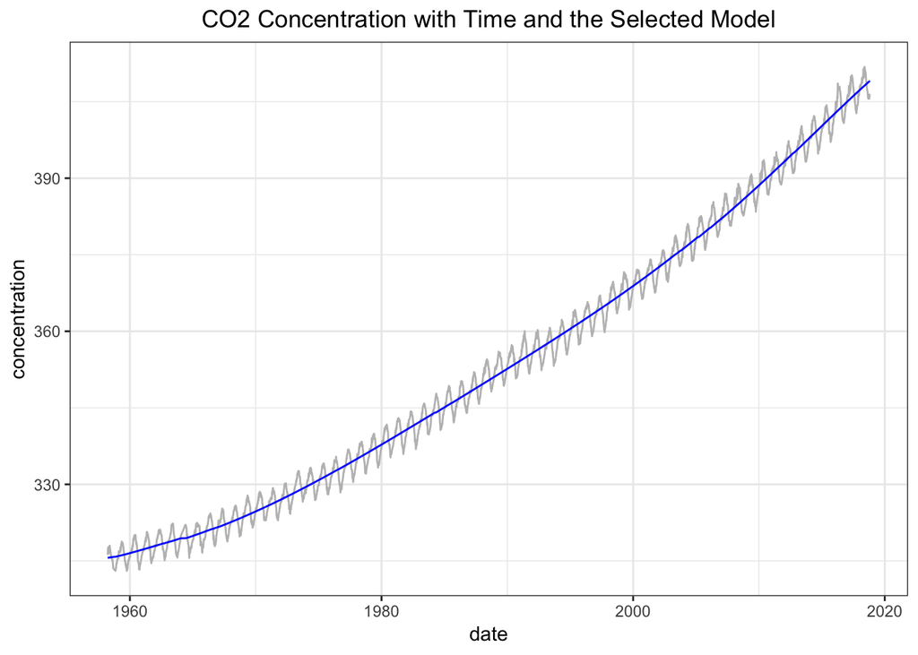

```r
#Making Prediktion
m6_predict <- data.frame(concentration = predict(m6, weekly_co2_concentration), date=weekly_co2_concentration$date)


#Observation of the performance of the selected model
ggplot(weekly_co2_concentration, aes(date, concentration)) +
    geom_line(color="gray") +
    geom_line(color="blue",data =m6_predict, aes(date, concentration)) +
    theme_bw() +
    ggtitle("CO2 Concentration with Time and the Selected Model") +
    theme(plot.title = element_text(hjust = 0.5))
```

## Prediction of CO2 concentration to 2025

```r
library(lubridate)
#Creation of new dates to make future prediction
lastDate =  tail(weekly_co2_concentration, 1)$date
while (!grepl("2050", lastDate, fixed=TRUE)) {
  lastDate <- lastDate + 7
  weekly_co2_concentration[nrow(weekly_co2_concentration) + 1,] = list(lastDate,0)
}
```

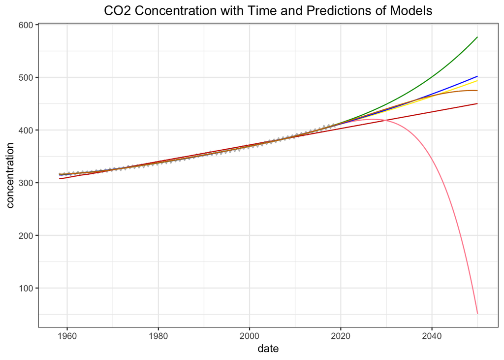

```r
library(ggplot2)
library("dplyr")

weekly_co2_concentration <- weekly_co2_concentration %>% mutate(index = row_number())
weekly_co2_concentration <- weekly_co2_concentration %>% mutate(index2 = row_number()^2)
weekly_co2_concentration <- weekly_co2_concentration %>% mutate(index3 = row_number()^3)
weekly_co2_concentration <- weekly_co2_concentration %>% mutate(index4 = row_number()^4)
weekly_co2_concentration <- weekly_co2_concentration %>% mutate(index5 = row_number()^5)
weekly_co2_concentration <- weekly_co2_concentration %>% mutate(index6 = row_number()^6)
weekly_co2_concentration <- weekly_co2_concentration %>% mutate(index7 = row_number()^7)

#Making Prediktion
prediction_linear <- data.frame(concentration = predict(m1, weekly_co2_concentration), date=weekly_co2_concentration$date)
prediction_quadratic <- data.frame(concentration = predict(m2, weekly_co2_concentration), date=weekly_co2_concentration$date)
prediction_initialy_selected <- data.frame(concentration = predict(m6, weekly_co2_concentration), date=weekly_co2_concentration$date)

prediction3 <- data.frame(concentration = predict(m3, weekly_co2_concentration), date=weekly_co2_concentration$date)
prediction4 <- data.frame(concentration = predict(m4, weekly_co2_concentration), date=weekly_co2_concentration$date)
prediction5 <- data.frame(concentration = predict(m5, weekly_co2_concentration), date=weekly_co2_concentration$date)

color_brown = "#CC7600"
color_green = "#029900"
color_yellow = "#FFEB00"
color_rose = "#FF8C9C"
color_red = "#CC1F00"

#Observation of the performance of the selected model
ggplot(weekly_co2_concentration[weekly_co2_concentration$date < "2018-10-27",], aes(date, concentration)) +
    geom_line(color="gray") +
    geom_line(color=color_red,data =prediction_linear, aes(date, concentration)) +
    geom_line(color=color_yellow,data =prediction_quadratic, aes(date, concentration)) +
    geom_line(color=color_rose,data =prediction_initialy_selected, aes(date, concentration)) +
    geom_line(color="blue",data =prediction3, aes(date, concentration)) +
    geom_line(color=color_green,data =prediction4, aes(date, concentration)) +
    geom_line(color=color_brown,data =prediction5, aes(date, concentration)) +
    theme_bw() +
    ggtitle("CO2 Concentration with Time and Predictions of Models") +
    theme(plot.title = element_text(hjust = 0.5))
```

Above graph shows the extrapolations of different models with colorful lines. After experiments, I decided to use model *m4* which is a polynomial model with degree 4 to extrapolate the CO2 concentration to 2025 (green line on the graph).

## Final Results

You can see the extrapolation results of the m4 in the following plot and table.

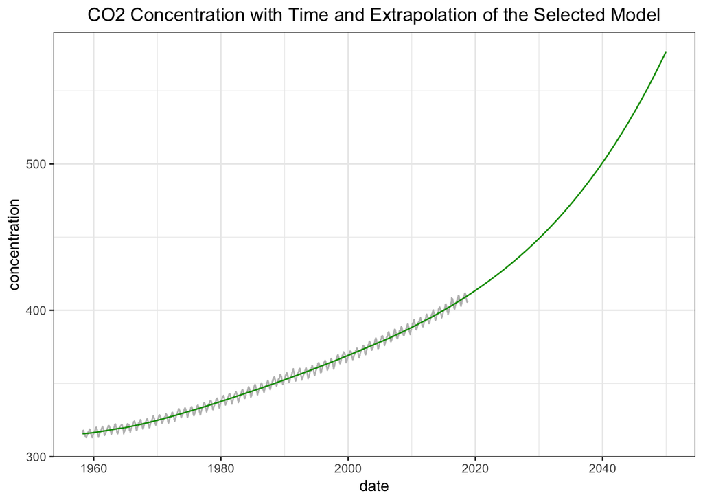

```r
ggplot(weekly_co2_concentration[weekly_co2_concentration$date < "2018-10-27",], aes(date, concentration)) +
    geom_line(color="gray") +
    geom_line(color=color_green,data =prediction4, aes(date, concentration)) +
    theme_bw() +
    ggtitle("CO2 Concentration with Time and Extrapolation of the Selected Model") +
    theme(plot.title = element_text(hjust = 0.5))
```

```r
select(prediction4[prediction4$date > "2018-10-27" & prediction4$date < "2025-12-31" ,], "date", "concentration")
```

```
##            date concentration
## 3092 2018-11-03      410.1721
## 3093 2018-11-10      410.2265
## 3094 2018-11-17      410.2809
## 3095 2018-11-24      410.3354
## 3096 2018-12-01      410.3899
## 3097 2018-12-08      410.4444
## 3098 2018-12-15      410.4990
## 3099 2018-12-22      410.5536
## 3100 2018-12-29      410.6082
## 3101 2019-01-05      410.6629
## 3102 2019-01-12      410.7176
## 3103 2019-01-19      410.7723
## 3104 2019-01-26      410.8271
## 3105 2019-02-02      410.8819
```

[output cut: 360 more lines]